# Fitting data to models

This page provides project description combined with fully executable code (enabled only in interactive mode).

Import the necessary libraries and setup some cosmetics.

```python
%matplotlib inline
import pandas as pd
import matplotlib.pyplot as plt
import numpy as np

import itertools    # for iterator-based python functions
import seaborn as sns; sns.set();

pd.set_option('display.mpl_style', 'default')
plt.rcParams['figure.figsize'] = (15, 3)
plt.rcParams['font.family'] = 'sans-serif'
```

### Project organisation

The projected is contained within the main class *AppMgr*, with the following classes embedded:

- *DataGenerator*
- *Fitter*
- *StatAnalyser*
- *Plotter*

#### *DataGenerator*

Its role is to generate data according to model provided and to simulate gaussian noise N(0, $\sigma$) in either of two forms:

- proportional -- the bigger the y-value the greater the noise. The motivation behind it is an inherent noise of a physical process, e.g. Poisson distribution based fluctuations of a number of nuclei that disintegrate in a unit time. The outcome is, then, (1 + N(0, $\sigma$) multiplied by pure model.
- white noise -- it's purely random and pertains to uncertainty of measurement as opposed to physical phenomenon intrinsic fluctuations. The outcome is, then, pure model plus N(0, $\sigma$)

The y values are computed for equidistant x arguments, so no x error is assumed.

#### *Fitter*

It's an object that exploits *curve_fit* function from *scipy.optimize* module. It is used twice per analysis: at first to fit model to data and then to fit gaussian to residual distributions obtained after fitting the data.

#### *Plotter*

This class enables plotting data and fit superimposed. It is, similarly to *Fitter* , used twice: for the sample data and for the residuals. It plots x and y data either as points or as histogram bars. In the latter case, it is assumed the histogram bins and their contents are provided as x and y data. This strategy was chosen instead of *pyplot.hist* method, which is a tool for both computing and ploting a histogram, in order to separate these two actions. In this way, *Plotter* is free from any computing and performs just data visualisation as one would expect.

#### Project execution

Project execution is invoked by *AppMgr*'s *__init__* method in the subsequent order:

- a sample model is assumed -- $sin(x)$ was used by picking specific parameters of more general *self.sin_linear*, which is $a \cdot sin(bx) + c$, so this could be easily altered. The model *self.sin_linear* is a method within the class just to store everything within the main class *AppMgr*. Similar strategy has been applied to other models: *gaussian*, *polyn_n*.
- lists of fit models and their parameters is created. They contain two elements: same fit model as sample model (the difference is, however, that sample has noise) and 3-rd degree polynomial.
- then, just for convenience x-axis is quantised and limited
- then data are generated iterating over various noise levels
- for each noise level data are generated accordingly and iteration over fit models is implemented
- single analysis (for specific noise and fit model) comprises: fitting model to the data, calculating residuals and chi squared and plotting the results on two plots: data with their fit and histogrammed residuals with their fit. The details are described in the above sections.

```python
class AppMgr(object):



    def __init__(self, noise=0.3, xRange=(0, np.pi*2), sampleSize=1e2):

        # assume model of data and its parameters
        model =  self.sin_linear #self.sin_with_noise #
        pars = [1, 1, 0] # [1, 0, 1, 1, 0] #

        # various fit models and initial guess of their params
        fit_models = [model, self.polyn_n]#self.sin_with_noise
        fit_pars_arr = [pars, (1, 1, 1, 1)]#[1, 0, 1, 1, 0]

        # prepare x-axis
        axis = np.linspace(xRange[0], xRange[1], sampleSize)


        # various noise levels
        for noise in np.linspace(.1, 0.6, 6):

            # generate data (with gaussian noise) using the model
            dg = self.DataGenerator((model,pars), axis, noise, noiseType="white")
            data = dg.generate()
            x, y = data[:, 0], data[:, 1]

            for i, fitMdlWithPars in enumerate(zip(fit_models, fit_pars_arr)):

                fit_model, fit_pars = fitMdlWithPars[0], fitMdlWithPars[1]

                # fit the model to the data; intercept statistics data
                ft = self.Fitter(fit_model, x, y, fit_pars)
                popt, pcov = ft.fit()


                # get fit_y points
                fit_y = fit_model(x, *popt)

                # calc residuals and chi squared / ndf
                sta = self.StatAnalyser(y, fit_y)
                resid = sta.residuals()
                chi2_per_ndf = sta.chi2ndf()

                # compute histogram of the residuals
                hist, bin_edges = np.histogram(resid, bins=np.linspace(-6, 6, 100),
                                               normed=True)
                bin_cntr = bin_edges[:-1] + 0.5 * (bin_edges[1] - bin_edges[0])

                # fit gaussian to the residuals
                res_ft = self.Fitter(self.gauss, bin_cntr, hist, (1,0,1))
                res_ft_parm, pcov = res_ft.fit()
                res_mu, res_sig = res_ft_parm[1], res_ft_parm[2]

                fit_res_y = self.gauss(bin_cntr, *res_ft_parm)


                # plot data with fit and residuals and chi squared / ndf

                label='$\sigma$ = %1.2f' % noise
                model_name = fit_model.__name__

                dat_tit = "Data and fit for noise param. " + label + " and model " + model_name
                res_tit = "Histogram of residuals for noise param. " + label + " and model " + model_name

                chi2_info = '$\chi^{2} / ndf =$ %1.2f' % (chi2_per_ndf)
                res_fit_info = '$\mu = %1.2f$ \n $\sigma = %1.2f$' % (res_mu, res_sig)

                # plot data with fit
                data_pl = self.Plotter(data=(x,y), fit=(x, fit_y), hist=False, title=dat_tit,
                                       info=chi2_info)
                # plot residuals with gaussian fit
                res_pl = self.Plotter(data=(bin_edges, hist), fit=(bin_cntr, fit_res_y), hist=True,
                                      title=res_tit, info=res_fit_info)



    def sin_linear(self, x, a, b, c):
        """

        model function

        """
        return a * np.sin(b * x) + c


    def gauss(self, x, *p):
        N, mu, sig = p
        return N * 1./(sig * np.sqrt(2*np.pi)) * np.exp(-1./2 * ((x-mu)/sig)**2 )

    def polyn_n(self,x, *p):
        """
        polynomial of nth-order
        """

        pol = np.poly1d(p)
        return pol(x)


    class DataGenerator(object):
        """

        generates data according to the params:
        - trueModel -- f(x), e.g. np.sin
        - noiseLevel -- sigma of normal distribution N(0, sigma)
        - xRange -- (x_min, x_max) tuple for x in [x_min ; x_max] range
        - sampleSize -- number of points returned
        - norm -- coefficient the resulting values are multiplied by

        The values returned are generated for equidistant arguments within xRange.
        Maybe x-values should be chosen randomly?
        Also, maybe add x-error?
        What about y-errors? Do we know them? Ignore them?

        """

        def __init__(self, modelWithPars, xaxis, noiseLevel, noiseType="white", norm=1.0):

            self.model, self.pars = modelWithPars[0], modelWithPars[1]
            self.axis = xaxis
            self.noise = noiseLevel
            self.norm = norm
            self.smpSize = len(self.axis)
            self.noiseType = noiseType


        def generate(self):
            """
            generates sample according to self.model and stores y values in the object, so they
            can be accessed later on

            returns 2-dim numpy array of x,y data
            """

            self.y = self.norm * (self.model(self.axis, *self.pars))
            noise = np.random.normal(0, self.noise, int(self.smpSize))

            if self.noiseType == "white":
                self.y = self.y + noise

            elif self.noiseType == "proportional":
                self.y = self.y * (1 + noise)

            return np.array( zip(self.axis, self.y) )


    class Fitter(object):

        def __init__(self, model, xdata, ydata, p0):

            self.model = model
            self.xdata = xdata
            self.ydata = ydata
            self.p0 = p0

        def fit(self):
            from scipy.optimize import curve_fit

            return curve_fit(self.model, self.xdata, self.ydata, self.p0 )



    class StatAnalyser(object):

        """
        calculates (y_i - y_fit)^2 """

        def __init__(self, data_y, model_y):

            self.data = data_y
            self.model = model_y


        def residuals(self):
            """

            calculates residuals normalised to mean value of data and model:
            res_i = (data_i - model_i) / model_i

            """

            return (self.data - self.model) / self.model

        def chi2ndf(self):
            return np.sqrt( ((self.data - self.model) ** 2 / abs(self.model)).sum() / len(self.data) )


    class Plotter(object):
        """

        Plots data assumed to be 2-dim numpy array

        """

        def __init__(self, data, fit, hist=False, title="", info=""):
            """

            data is 2-dim numpy array of x and generated y
            fit_model is a tuple of fit function and its params

            """
            self.x, self.y = data[0], data[1]
            self.fit_x, self.fit_y = fit[0], fit[1]
            self.hist = hist
            self.title = title
            self.info = info

            self.plot()


        def plot(self):

            fig, ax = plt.subplots(1, 1, figsize=(12, 10), sharex = False, sharey=False)

            # plot data
            if self.hist:
                ax.bar(self.x[:-1], self.y, width=(self.x[1] - self.x[0]), alpha=0.5)
            else:
                ax.plot(self.x, self.y, 'bo', label='data')

            # plot fit
            ax.plot(self.fit_x, self.fit_y, 'r-', label='fit')


            # cosmetics
#             if self.title is not None:
            ax.set_title(self.title)

            ax.text(.6 * max(self.x), .6 * max(self.y), self.info, ha='center',
                     size=18, alpha=0.5, color='red')

            ax.legend()
```

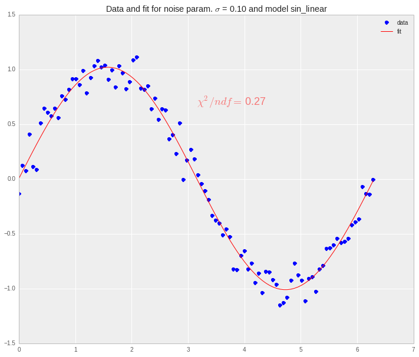

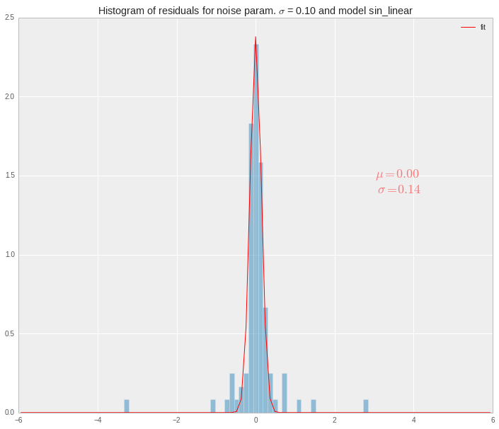

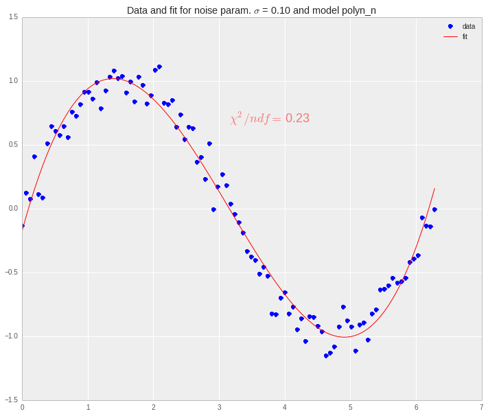

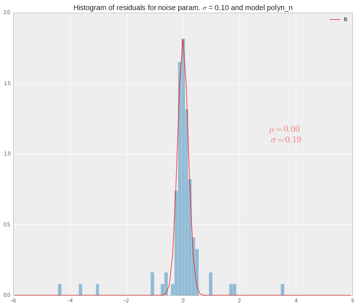

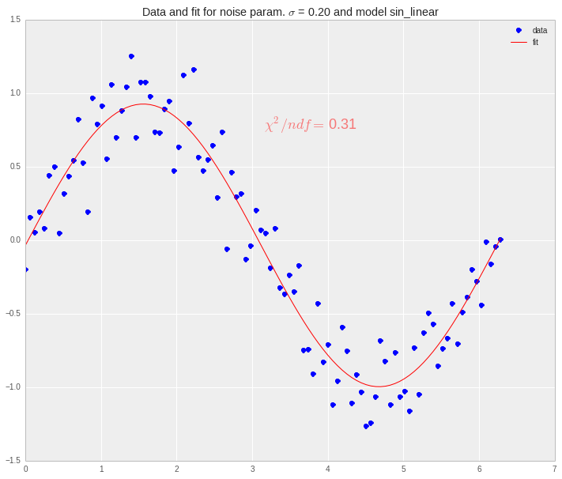

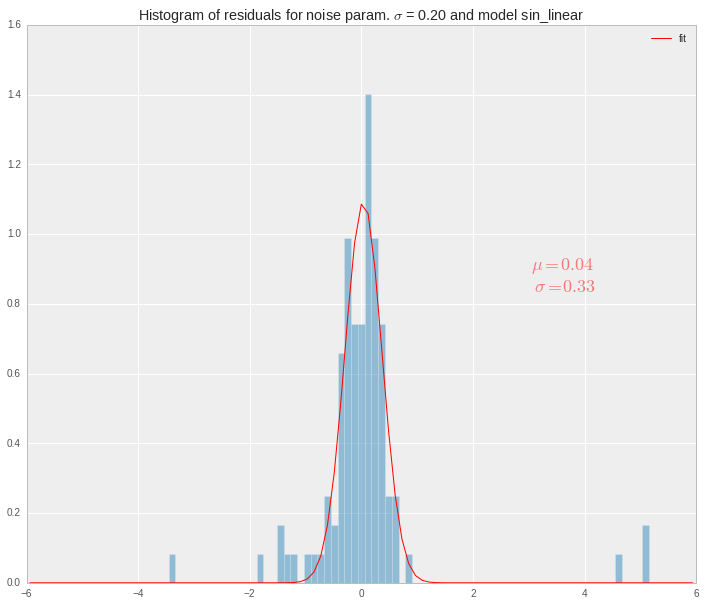

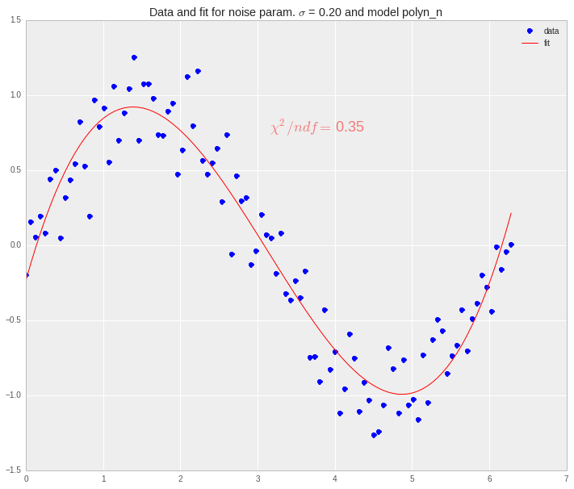

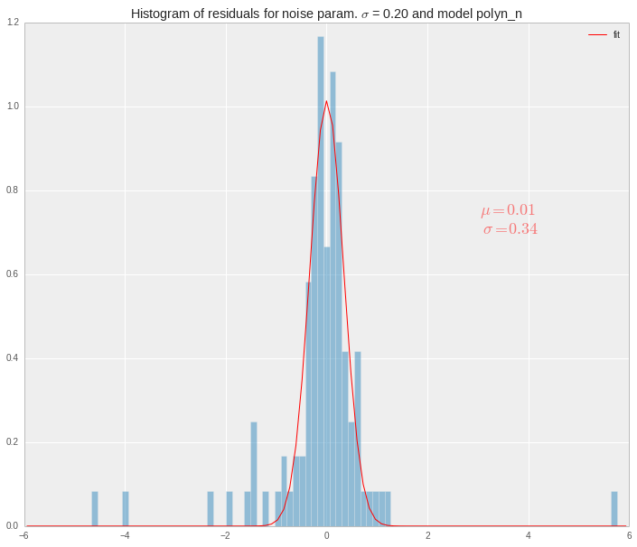

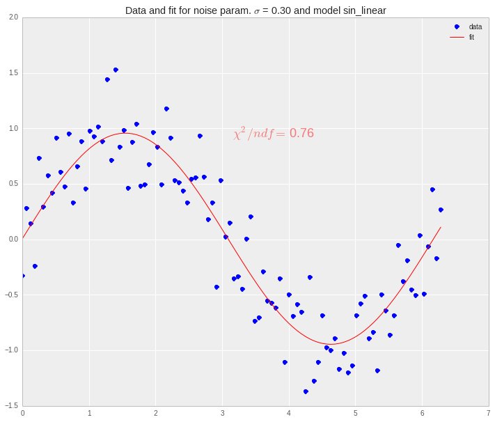

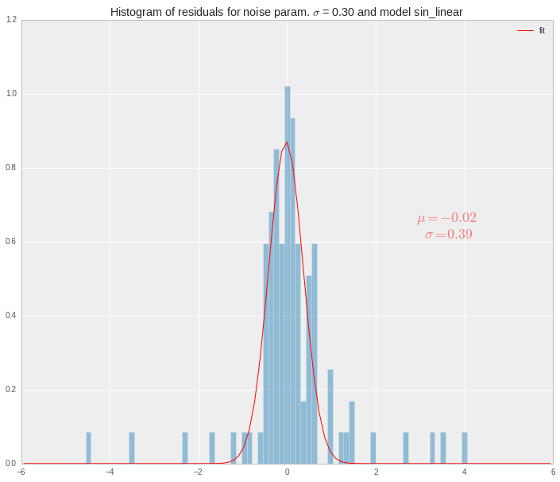

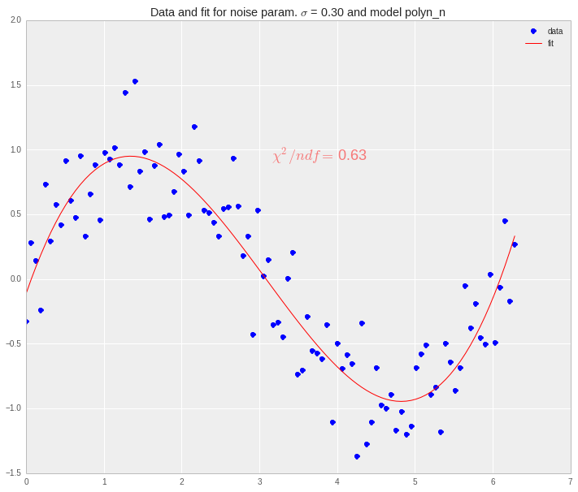

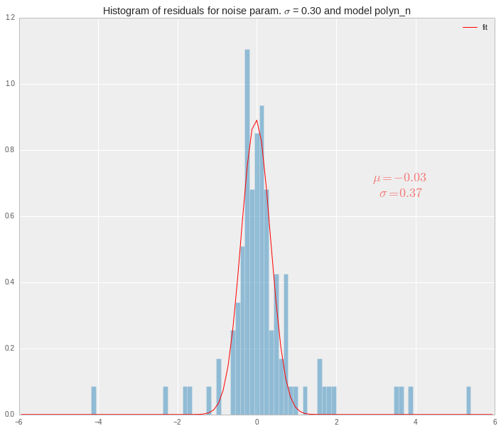

[12 more figures not shown]

```python
start = AppMgr()
```

### Analysing the results

We can see that increasing the noise spreads out residuals distribution and increases $\chi^2$ per number of degrees of freedom, as expected. At $\sigma=0.50$ the $\chi^2 / ndf$ is greater than 1 in both fit models used (sine and 3-rd order polynomial). It means, the models stop being reliable as the noise increases and perhaps a better model would be a convolution of signal and noise.